# Introduction to TBsim

# Plotting results

After execution, to read in all output information:

```r
folder <- "~/tb_run/output"
info  <- tb_read_output(folder, "header")
outc  <- tb_read_output(folder, "outcome")
bact  <- tb_read_output(folder, "bact")
conc  <- tb_read_output(folder, "conc")
dose  <- tb_read_output(folder, "dose")
eff   <- tb_read_output(folder, "effect")
kill  <- tb_read_output(folder, "kill")
imm   <- tb_read_output(folder, "immune")
macro <- tb_read_output(folder, "macro")
adh <- tb_read_output(folder, "adherence")
```

*Note: not all of the above output might be available. This will depend on the arguments supplied to `tb_new_sim()`.*

We can then plot the imported data. The only function that is required for this is the `tb_plot` function, which will automatically create the appropriate plot for the data. The `tb_plot()` requires only two arguments, i.e. the main simulation object (`info` in this case), and the relevant data you want to plot.

Note that the output from `tb_plot()` is a ggplot2 object, so you can add additional layout specifications on top of the output (such as `xlim()` or `theme()`). Alternatively, it should be fairly straightforward to write custom functions to plot the relevant data object in different ways, if required.

```r
## Plot outcome data
tb_plot (info, outc)
```

[output not shown]

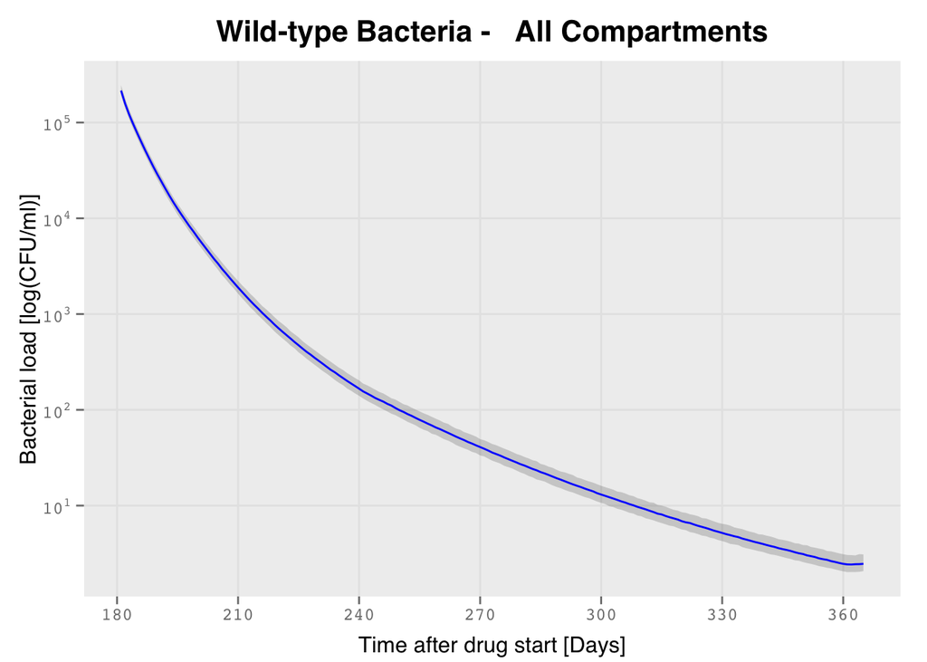

```r
## Plot bacterial data (wild type)
tb_plot (info, bact, type="wild")
```

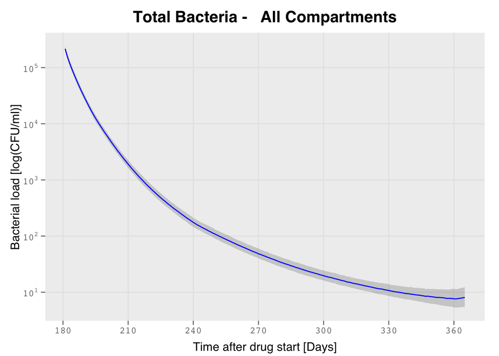

```r
## Plot bacterial data (total)
tb_plot (info, bact, type="total")
```

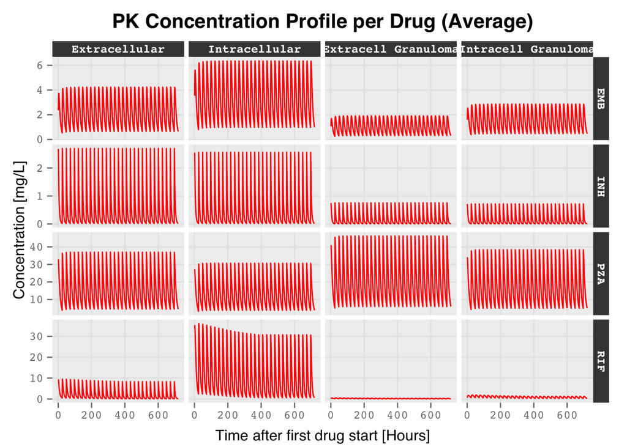

```r
## Plot concentrations
tb_plot (info, conc)
```

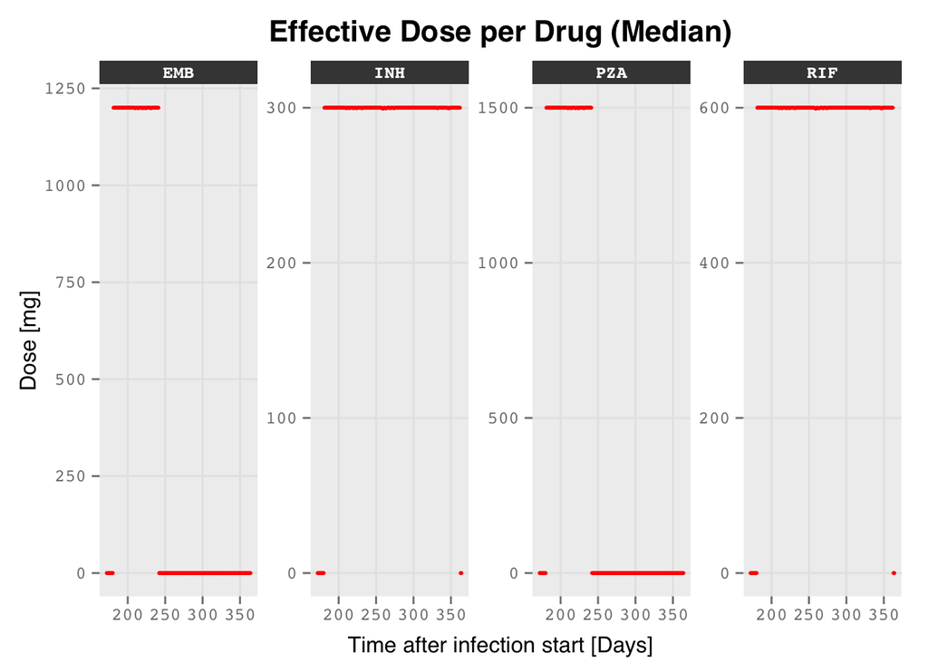

```r
## Plot doses
tb_plot (info, dose)
```

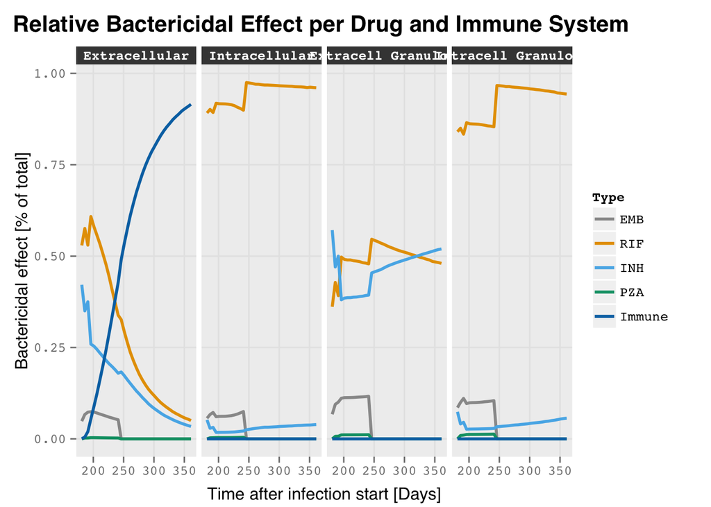

```r
## Plot effect
tb_plot (info, eff)
```

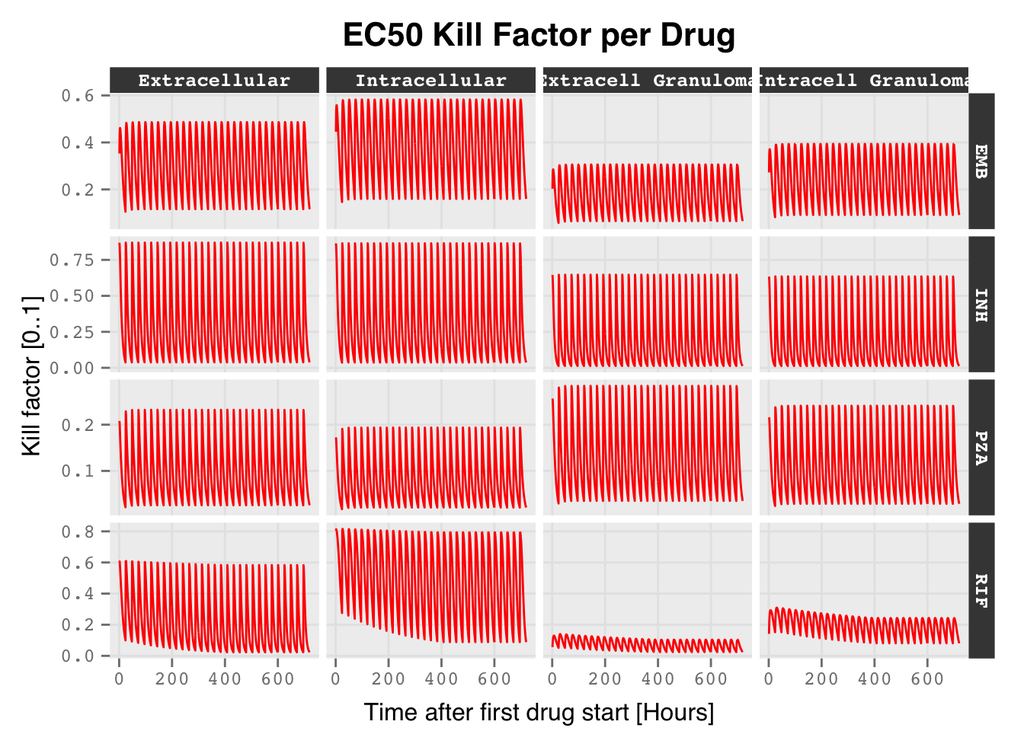

```r
## plot Kill
tb_plot (info, kill)
```

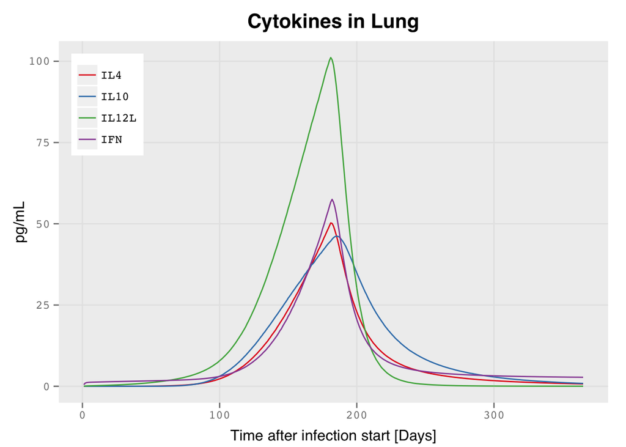

```r
## Plot immune results
imm_pl <- tb_plot(info, imm)
imm_pl$cytokines_lung
```

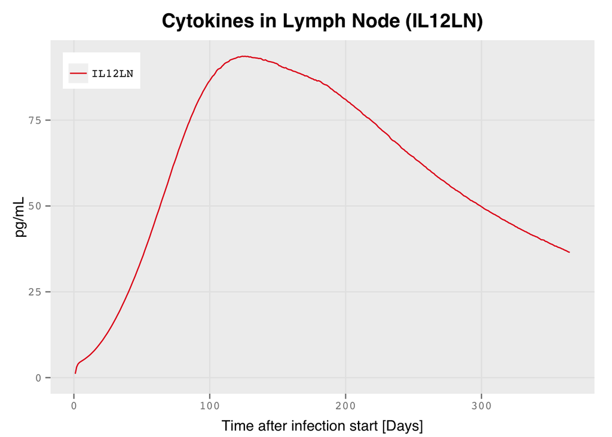

```r
imm_pl$cytokines_lymph
```

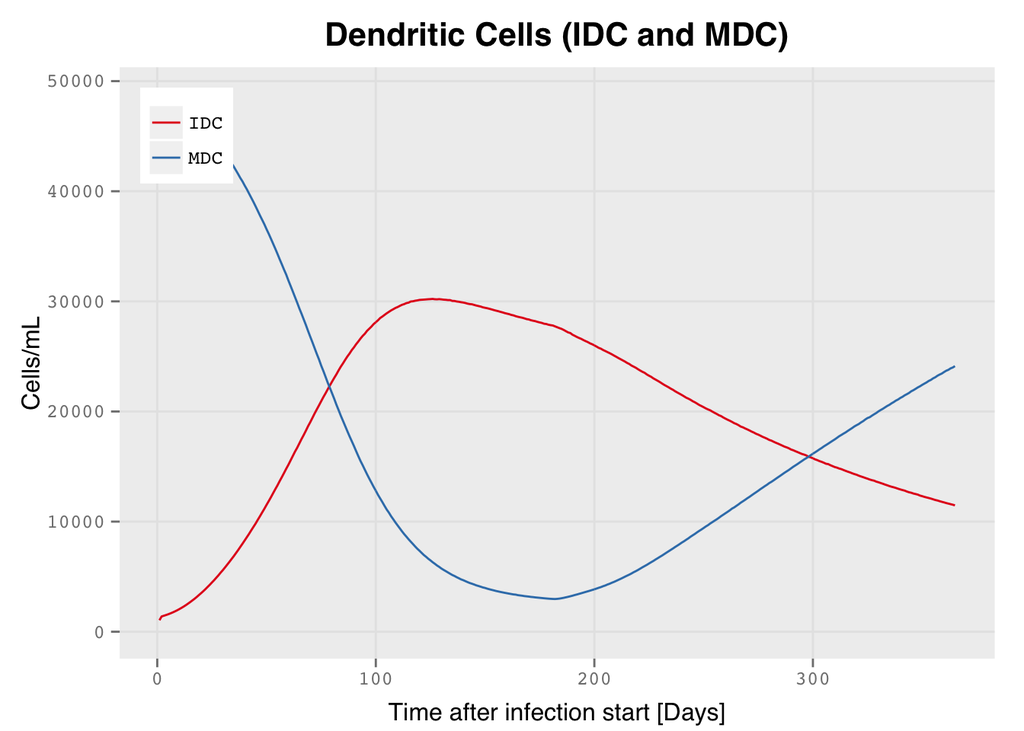

```r
imm_pl$cytokines_dendr
```

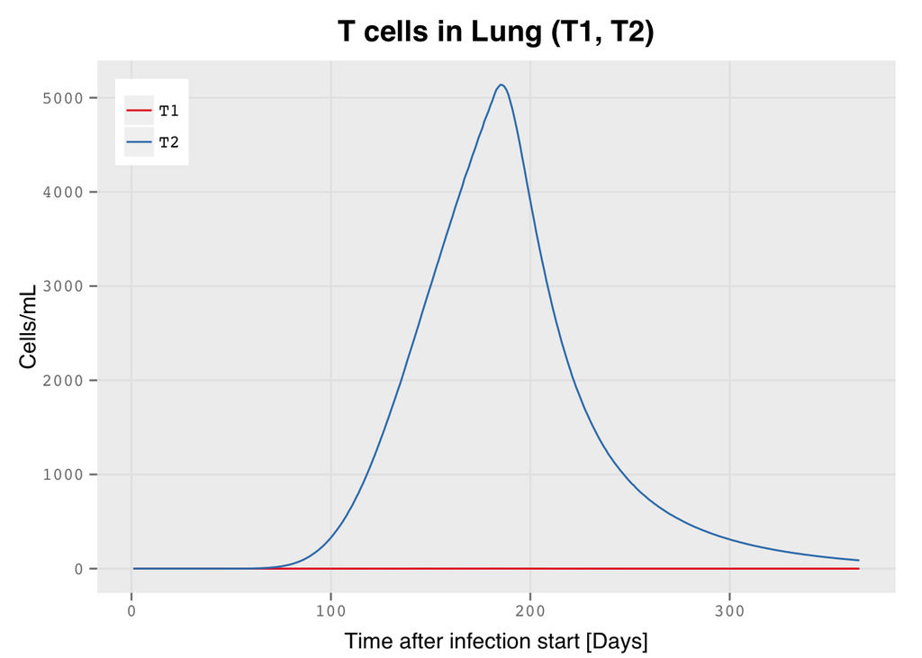

```r
imm_pl$t_cells_lung
```

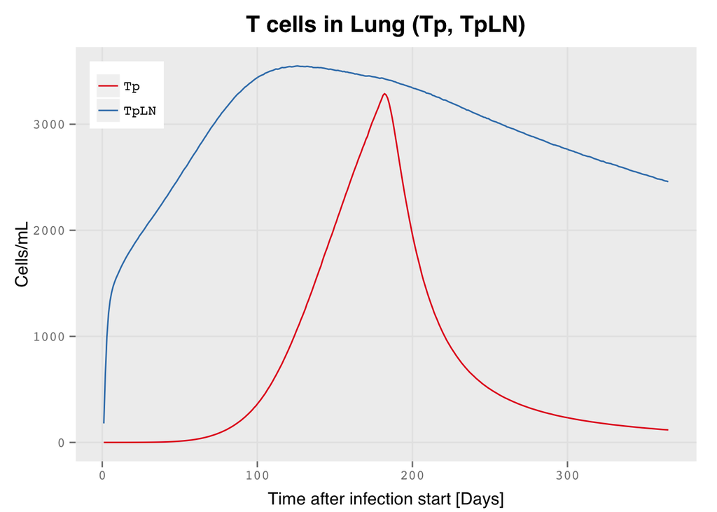

```r
imm_pl$t_helper
```

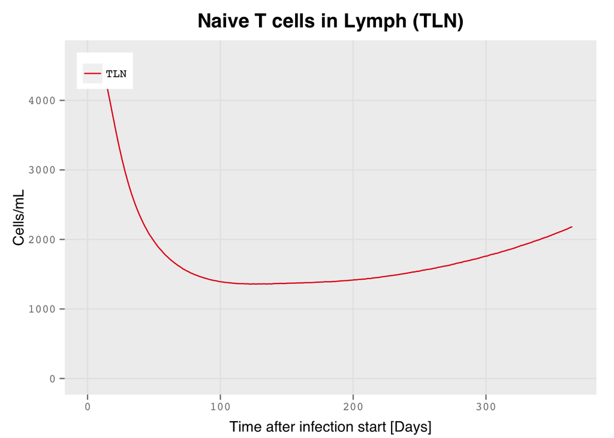

```r
imm_pl$t_naive
```

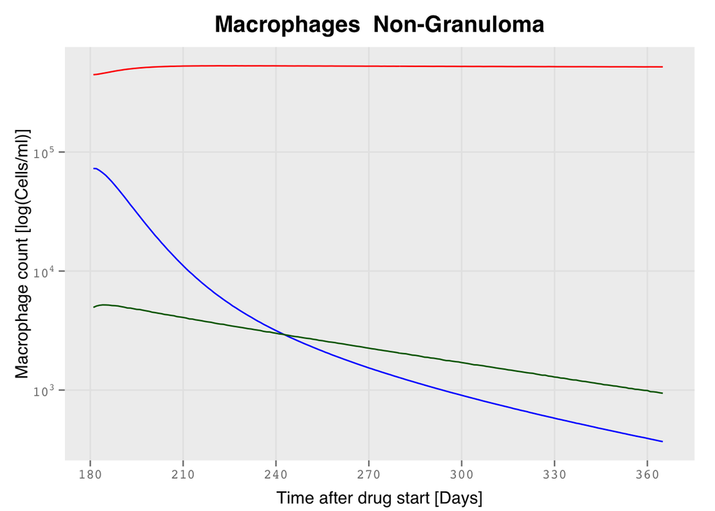

```r
## Plot macrophages
tb_plot(info, macro)
```

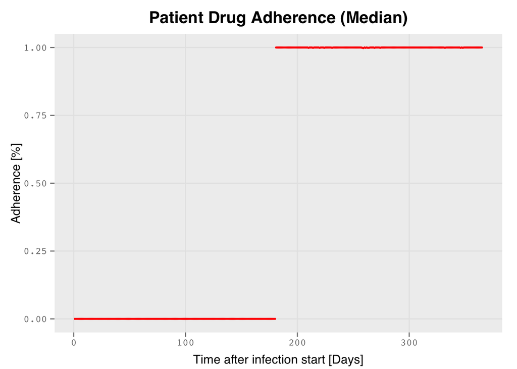

```r
## Plot adherence
tb_plot(info, adh)
```